# Chapter 2&3 Practice and homeworks

The layout for the following notebooks will first go through the book chapter’s practice section and then tackle the homeworks provided online. In between, I might copy code sections from the book to facilitate the practical aspects associated to the learning and application of the methods of interest.

*Disclaimer: The answers provided here are not only mine and are not necessarily correct*

See Sources here containing some of the copied answers in this notebook:

- [link1](https://rpubs.com/andersgs/my_solutions_chapter2_statrethink)
- [link2](http://rstudio-pubs-static.s3.amazonaws.com/326789_e280ba45916a400f9556212409406da2.html)

### Practice 2.6.

##### **Easy:**

- **2E1.** The expressions that correspond to the “The probability of rain on Monday” are: Pr(rain|Monday) and Pr(rain,Monday) / Pr(Monday) –
- **2E2.** The probability that it is Monday given that it is raining corresponds to the expression Pr(Monday|Rain)
- **2E3.** Pr(Monday|Rain) and Pr(rain|Monday) * Pr(Monday) / Pr(rain) [according to Bayes rule] corresponds to the statement: “The probability that it is Monday given that it is raining”
- **2E4.** With regards to the global tossing example from the chapter, saying that “the probability of water is 0.7” implies that given our limited knowledge and based on the outcomes of the experiment, our best guess of the true proportion of water in the globe is 0.7. –

##### **Medium:**

> Recalling the global tossing model from chapter 2

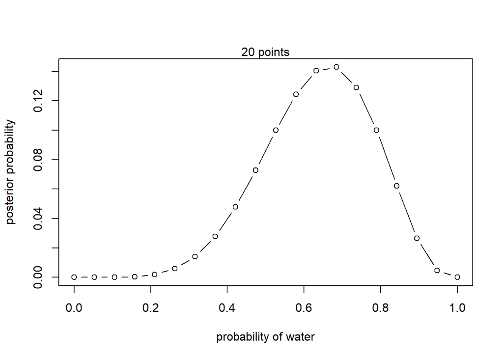

- **2M1.& 2M2**
  - In case the set of observation was: (1) W, W, W

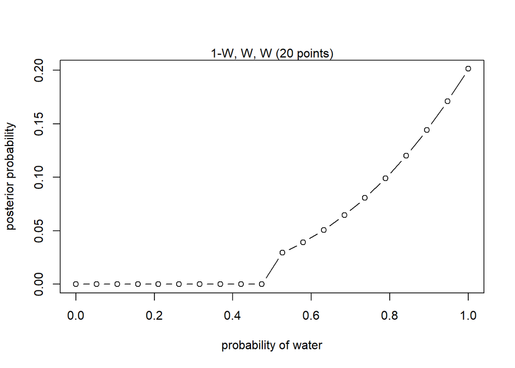

  - In case the set of observation was: (2) W, W, W, L

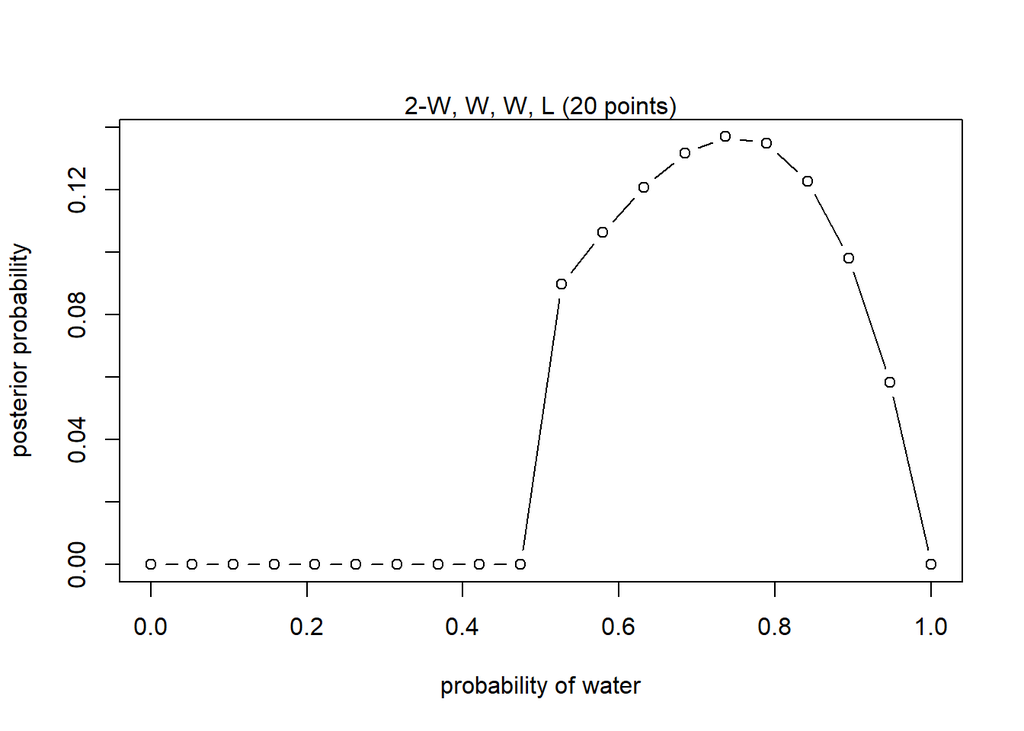

  - In case the set of observation was: (3) L, W, W, L, W, W, W

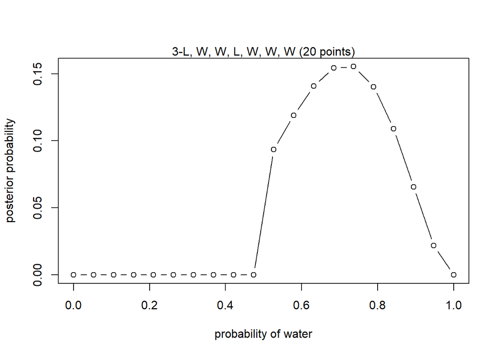

- **2M3** –

```r
p_E = 1/2 # probability that globe is Earth
p_M = 1/2 # probability that globe is Mars

p_land_E = 0.3 # probability land given Earth p(land|Earth)
p_land_M = 1.0 # probability land given Mars p(land|Mars)

p_land = p_land_E*p_E + p_land_M*p_M # probability of land

# What is p(Earth|land) ?
## p(Earth|land) = (p(land|Earth) * p(Earth)) / p(land)
p_earth_L = (p_land_E * p_E)/p_land
p_earth_L
```

```
## [1] 0.2307692
```

- **2M4** Card1: B/B Card2: B/W Card3: W/W

If we observed one black side up, there are 2 ways of producing the black side up if we pick the B/B card and one way if we pick the B/W card, so in total, 2 of 3 ways are consistent with the other side of the card being black. The answer is 2/3.

- **2M5** With an extra B/B card:

If we observe one black side up, there are 4 ways of producing the black side up (2 for each B/B card) and 1 for picking the B/W card. The total probability that the other side is black is thus: 4/5

- **2M6** Card1: B/B Card2: B/W Card3: W/W

Black sides are heavier than cards with white sides so it is less likely that a card with black sides is pulled from the bag.

There are still 2 ways for B/B to produce a black side up, 1 way for B/W and zero ways for W/W. But according to the prior information, there is 1 way to get the B/B card, 2 ways to get the B/W card and 3 ways to get the W/W card so:

The total ways for the B/B card to produce a black side up are 2 * 1 and the total ways for the B/W card to produce a black side up are 1 * 2.

So, there are 4 ways total to see a black side up and 2 of these come from the B/B card hence the probability that the other side is black is now at 0.5